Froude_Lilith  
Hands On Exercise 1  
10/24/2025

# **1. Problem Introduction & Motivation**

*(no code needed for this section)*

This project aims to build a machine learning model to predict the presence of heart disease in patients based on a set of medical attributes. The problem is a binary classification task, where the model will learn to distinguish between two classes: patients with heart disease (target = 1) and patients without heart disease (target = 0).

The motivation for this model is significant. Heart disease is a leading cause of death globally, and the ability to accurately predict its presence using readily available patient data can be a powerful tool for early diagnosis. An effective model could assist clinicians in identifying high-risk patients who may require further testing or immediate intervention, potentially improving patient outcomes and reducing healthcare costs.

# **2. Data Preparation (EDA)**

*(code needed for this section)*

In this section, we will load, inspect, clean, and prepare the heart_disease.csv dataset for modeling.

### **2.1. Loading the Data**

1. We start by using drive.mount() to connect our Google Drive, which lets us access our files.
2. We then import our main libraries: pandas to load and manage the data table, os to navigate our file folders, and matplotlib and seaborn to create plots.

Finally, we use a few key functions:

3. %cd (a magic command) to change our directory to where the file is stored.
4. pd.read_csv() to load the heart_disease.csv file.

```python
import pandas as pd
import matplotlib.pyplot as plt
import seaborn as sns
from google.colab import drive
import os

# 1. Mount Google Drive
drive.mount('/content/drive')

# 2. Change directory to your 'Colab Notebooks' folder
#    Make sure your 'heart_disease.csv' file is in this folder
%cd /content/drive/MyDrive/Colab Notebooks

# 3. Verify the current directory (optional, but good practice)
print(f"Current working directory: {os.getcwd()}")

# Set a consistent style for plots
sns.set_style("whitegrid")

# 4. Load the dataset from the current directory
file_path = "heart_disease.csv"
df = pd.read_csv(file_path)

# 5. Inspect the first few rows
print("--- Data Head ---")
print(df.head())

# 6. Get information about column types and missing values
print("\n--- Data Info ---")
df.info()

# 7. Get descriptive statistics
print("\n--- Data Describe ---")
print(df.describe())
```

```
/content/drive/MyDrive/Colab Notebooks
Current working directory: /content/drive/MyDrive/Colab Notebooks
--- Data Head ---
   heart_disease   age     sex  max_heart_rate angina_level  non_anginal_pain
0              0  69.0    male             131           No                 0
1              0  69.0  female             151           No                 0
2              0   NaN  female             114           No                 0
3              1  65.0    male             174           No                 0
4              0  64.0    male             144         Mild                 0

--- Data Info ---
<class 'pandas.core.frame.DataFrame'>
RangeIndex: 297 entries, 0 to 296
Data columns (total 6 columns):
 #   Column            Non-Null Count  Dtype
---  ------            --------------  -----
 0   heart_disease     297 non-null    int64
 1   age               268 non-null    float64
 2   sex               297 non-null    object
 3   max_heart_rate    297 non-null    int64
 4   angina_level      277 non-null    object
 5   non_anginal_pain  297 non-null    int64
dtypes: float64(1), int64(3), object(2)
memory usage: 14.1+ KB

--- Data Describe ---
       heart_disease         age  max_heart_rate  non_anginal_pain
count     297.000000  268.000000      297.000000        297.000000
mean        0.461279   54.250000      146.380471          0.279461
std         0.499340    9.039292       38.500000          0.449492
min         0.000000   29.000000     -170.000000          0.000000
25%         0.000000   47.750000      132.000000          0.000000
50%         0.000000   55.000000      152.000000          0.000000
75%         1.000000   60.000000      165.000000          1.000000
max         1.000000   77.000000      202.000000          1.000000
```

### **2.2. Data Cleaning**

```python
# Check the shape before cleaning
print(f"Original number of rows: {len(df)}")

# Remove rows with anomalous negative values in 'max_heart_rate'
df_cleaned = df[df['max_heart_rate'] > 0].copy()

# Check the shape after cleaning
print(f"Number of rows after removing negative heart rates: {len(df_cleaned)}")

# Display statistics for the cleaned data
print("\n--- Cleaned Data Describe ---")
print(df_cleaned.describe())
```

```
Original number of rows: 297
Number of rows after removing negative heart rates: 294

--- Cleaned Data Describe ---
       heart_disease         age  max_heart_rate  non_anginal_pain
count     294.000000  265.000000      294.000000        294.000000
mean        0.462585   54.218868      149.500000          0.278912
std         0.499448    9.080304       23.012795          0.449229
min         0.000000   29.000000       71.000000          0.000000
25%         0.000000   47.000000      133.000000          0.000000
50%         0.000000   55.000000      152.500000          0.000000
75%         1.000000   60.000000      165.750000          1.000000
max         1.000000   77.000000      202.000000          1.000000
```

### **2.3. Handling Missing Data**

From the .info() output, we identified missing values in the age and angina_level columns (and possibly max_heart_rate after cleaning). We will handle these as follows:

**1. age (Numerical):** We will impute the missing values using the median age. The median is more robust to outliers than the mean.

**2. max_heart_rate (Numerical):** We will also impute any missing values here with the median.

**3. angina_level (Categorical):** We will impute the missing values using the mode (the most frequent value).

```python
# Check missing value counts
print("--- Missing Values Before Imputation ---")
print(df_cleaned.isnull().sum())

# Impute 'age' with the median
age_median = df_cleaned['age'].median()
# FIX: Reassign the column instead of using inplace=True
df_cleaned['age'] = df_cleaned['age'].fillna(age_median)
print(f"\nImputed 'age' with median value: {age_median}")

# Impute 'max_heart_rate' with the median
hr_median = df_cleaned['max_heart_rate'].median()
# FIX: Reassign the column
df_cleaned['max_heart_rate'] = df_cleaned['max_heart_rate'].fillna(hr_median)
print(f"Imputed 'max_heart_rate' with median value: {hr_median}")

# Impute 'angina_level' with the mode
angina_mode = df_cleaned['angina_level'].mode()[0]
# FIX: Reassign the column
df_cleaned['angina_level'] = df_cleaned['angina_level'].fillna(angina_mode)
print(f"Imputed 'angina_level' with mode value: '{angina_mode}'")

# Verify that there are no more missing values
print("\n--- Missing Values After Imputation ---")
print(df_cleaned.isnull().sum())
```

```
--- Missing Values Before Imputation ---
heart_disease        0
age                 29
sex                  0
max_heart_rate       0
angina_level        20
non_anginal_pain     0
dtype: int64

Imputed 'age' with median value: 55.0
Imputed 'max_heart_rate' with median value: 152.5
Imputed 'angina_level' with mode value: 'No'

--- Missing Values After Imputation ---
heart_disease       0
age                 0
sex                 0
max_heart_rate      0
angina_level        0
non_anginal_pain    0
dtype: int64
```

### **2.4. Transforming**

Machine learning models require numerical input. Our dataset has two categorical columns: sex (with values like 'male', 'female') and angina_level (with values like 'No', 'Mild', 'Severe'). We will convert these into numerical form using one-hot encoding (via pd.get_dummies). We'll set drop_first=True to avoid multicollinearity, which is good practice.

```python
# Identify the categorical columns
categorical_cols = ['sex', 'angina_level']

# Check unique values before transformation
print("\n--- Unique Values Before Transformation ---")
for col in categorical_cols:
    print(f"Column '{col}': {df_cleaned[col].unique()}")

# Apply one-hot encoding
df_transformed = pd.get_dummies(df_cleaned, columns=categorical_cols, drop_first=True)

# Display the head of the transformed dataframe
print("\n--- Transformed Data Head ---")
print(df_transformed.head())

# Check the new structure
print("\n--- Transformed Data Info ---")
df_transformed.info()
```

```
--- Unique Values Before Transformation ---
Column 'sex': ['male' 'female']
Column 'angina_level': ['No' 'Mild' 'Severe']

--- Transformed Data Head ---
   heart_disease   age  max_heart_rate  non_anginal_pain  sex_male  \
0              0  69.0             131                 0      True
1              0  69.0             151                 0     False
2              0  55.0             114                 0     False
3              1  65.0             174                 0      True
4              0  64.0             144                 0      True

   angina_level_No  angina_level_Severe
0             True                False
1             True                False
2             True                False
3             True                False
4            False                False

--- Transformed Data Info ---
<class 'pandas.core.frame.DataFrame'>
Index: 294 entries, 0 to 296
Data columns (total 7 columns):
 #   Column               Non-Null Count  Dtype
---  ------               --------------  -----
 0   heart_disease        294 non-null    int64
 1   age                  294 non-null    float64
 2   max_heart_rate       294 non-null    int64
 3   non_anginal_pain     294 non-null    int64
 4   sex_male             294 non-null    bool
 5   angina_level_No      294 non-null    bool
 6   angina_level_Severe  294 non-null    bool
dtypes: bool(3), float64(1), int64(3)
memory usage: 12.3 KB
```

### **2.5. Summarizing and Visualization**

Now that the data is clean and in the correct format, we can create visualizations to understand distributions and relationships.

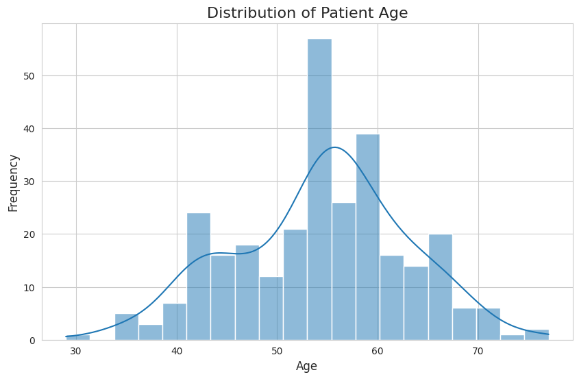

```python
#Histogram: Age Distribution
#This plot shows the distribution of patient ages.

# Plot histogram for 'age'
plt.figure(figsize=(10, 6))
sns.histplot(df_transformed['age'], kde=True, bins=20)
plt.title('Distribution of Patient Age', fontsize=16)
plt.xlabel('Age', fontsize=12)
plt.ylabel('Frequency', fontsize=12)
plt.show() # Use plt.show() to display the plot in the notebook
```

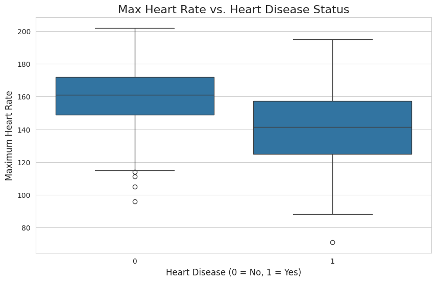

```python
#Boxplot: Max Heart Rate by Heart Disease
#This plot helps us see if there's a difference in max_heart_rate between patients with and without heart disease.

# Plot boxplot for 'max_heart_rate' vs 'heart_disease'
plt.figure(figsize=(10, 6))
sns.boxplot(x='heart_disease', y='max_heart_rate', data=df_transformed)
plt.title('Max Heart Rate vs. Heart Disease Status', fontsize=16)
plt.xlabel('Heart Disease (0 = No, 1 = Yes)', fontsize=12)
plt.ylabel('Maximum Heart Rate', fontsize=12)
plt.show()
```

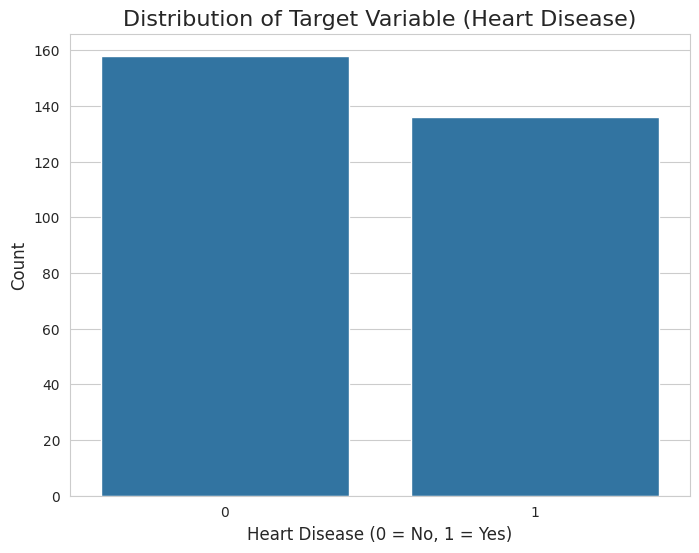

```python
#Countplot: Target Variable Distribution
#This plot shows the balance between our two target classes.

# Plot countplot for the target variable 'heart_disease'
plt.figure(figsize=(8, 6))
sns.countplot(x='heart_disease', data=df_transformed)
plt.title('Distribution of Target Variable (Heart Disease)', fontsize=16)
plt.xlabel('Heart Disease (0 = No, 1 = Yes)', fontsize=12)
plt.ylabel('Count', fontsize=12)
plt.show()
```

# **3. Model Selection**

*(No code needed for this section)*

For this binary classification problem, a Logistic Regression model is a strong and appropriate initial choice.

### **Reasoning:**

**Interpretability:** Logistic Regression is a linear model that is highly interpretable. It provides coefficients for each feature, allowing us to understand how each variable (like age or sex_male) contributes to the predicted probability of heart disease.

**Efficiency:** It is computationally simple and fast to train, making it an excellent baseline model.

**Probabilistic Output:** It directly outputs a probability (from 0 to 1) of a patient having heart disease, which is often more useful in a medical context than a simple "yes" or "no" answer. A doctor might treat a patient with a 90% predicted probability very differently than one with a 55% probability.

While other models like Decision Trees, Random Forests, or Support Vector Machines (SVMs) could also be used, Logistic Regression provides the best balance of simplicity, interpretability, and performance for an initial analysis.

# **4. Model Evaluation**

*(No code needed for this section)*

To evaluate the performance of our classification model, we cannot rely on accuracy alone, especially in a medical context where the cost of a wrong answer can be high. We would use the following methods:

### **1. Train-Test Split**

First, we must split our data into a training set (to build the model) and a testing set (to evaluate it on unseen data). This prevents overfitting and gives a realistic measure of performance.

### **2. Confusion Matrix**

This $2 \times 2$ table is the foundation for most other metrics. It shows:

- **True Positives (TP):** Correctly predicted "Heart Disease."
- **True Negatives (TN):** Correctly predicted "No Heart Disease."
- **False Positives (FP):** Incorrectly predicted "Heart Disease" (a "false alarm").
- **False Negatives (FN):** Incorrectly predicted "No Heart Disease" (a "missed diagnosis").

### **3. Key Evaluation Metrics**

- **Accuracy:** $(TP + TN) / (Total)$. The percentage of all predictions that were correct. It can be misleading if the classes are imbalanced.
- **Precision:** $TP / (TP + FP)$. Of all patients the model predicted had heart disease, how many actually did? High precision minimizes false positives.
- **Recall (Sensitivity):** $TP / (TP + FN)$. Of all patients who actually had heart disease, how many did the model correctly identify? In this medical case, recall is likely the most important metric, as failing to identify a sick patient (a False Negative) is often more dangerous than a false alarm (a False Positive).
- **F1-Score:** The harmonic mean of Precision and Recall $(2 \cdot (Precision \cdot Recall) / (Precision + Recall))$. It provides a single score that balances both metrics.

### **4. ROC Curve (Receiver Operating Characteristic) and AUC (Area Under the Curve)**

- The **ROC** curve plots the True Positive Rate (Recall) against the False Positive Rate at various probability thresholds.
- The **AUC** score (from 0 to 1) measures the entire area under this curve. A score of 1.0 is a perfect model, while a score of 0.5 is no better than random guessing. This metric is very robust as it evaluates the model's performance across all possible thresholds.

# **5. Submission and Deliverables**

**Jupyter Notebook File (.ipynb):** Submit the Jupyter Notebook file that you created via Google Colab, containing the Python code used to analyze the data and build the ML model.

**HTML File (.html):** Submit the HTML file exported from your Notebook. Crucially, make sure that both the code outputs and the final results are clearly visible and included in this HTML file.

```python
# --- CODE TO GENERATE YOUR HTML FILE ---

# 1. IMPORTANT: Before running this cell, you MUST rename this notebook.
#    Go to "File > Rename..." at the top of the Colab window.
#    Rename it to your "lastname_firstname_hw1.ipynb"
#    Make sure it is saved in your "Colab Notebooks" folder.

# 2. Set your file name here:
notebook_filename = "Froude_Lilith_hw1.ipynb" # <-- Make sure this matches!

# 3. Define the full path to your notebook
notebook_path = f"/content/drive/MyDrive/Colab Notebooks/{notebook_filename}"

# 4. Run the conversion command
# This will find your .ipynb file and create an .html file
# with the same name, right next to it in your Google Drive.
print(f"Attempting to convert {notebook_path} to HTML...")

!jupyter nbconvert --to html "{notebook_path}"

print(f"\nDone! Check your 'Colab Notebooks' folder for the HTML file.")
```

```
Attempting to convert /content/drive/MyDrive/Colab Notebooks/Froude_Lilith_hw1.ipynb to HTML...
[NbConvertApp] Converting notebook /content/drive/MyDrive/Colab Notebooks/Froude_Lilith_hw1.ipynb to html
[NbConvertApp] WARNING | Alternative text is missing on 3 image(s).
[NbConvertApp] Writing 425918 bytes to /content/drive/MyDrive/Colab Notebooks/Froude_Lilith_hw1.html

Done! Check your 'Colab Notebooks' folder for the HTML file.
```